# Project: European Soccer Database

- Introduction
- Data Wrangling
- Exploratory Data Analysis
- Conclusions

## Introduction

**Dataset Description**

- +25,000 matches
- +10,000 players
- 11 European Countries with their lead championship
- Seasons 2008 to 2016
- Players and Teams' attributes* sourced from EA Sports' FIFA video game series, including the weekly updates
- Team line up with squad formation (X, Y coordinates)
- Betting odds from up to 10 providers
- Detailed match events (goal types, possession, corner, cross, fouls, cards etc…) for +10,000 matches

If you want to access or download this dataset, you can get more details [here](https://www.kaggle.com/hugomathien/soccer).

let's import some libraries to help us in investigating the databas.

```python
import pandas as pd
import sqlite3
import numpy as np
%matplotlib inline
import matplotlib.pyplot as plt
import seaborn as sns
```

as the dataset is SQLite, so we want to make a connection to the database to be able to read its tables.

```python
# SQLite database full path
database = 'database.sqlite'

# database connection
conn = sqlite3.connect(database)
```

## Data Wrangling

After we have connected successfully with the database, we will start to read the tables inside the database and play with this data to get good insights. so we will start in pandas framework with simple SQL queries.

> **Tip**: This section requires a basic understanding of **SQL** and **pandas**.

First, we need to know what are the tables inside the database. let's check with a simple sql query

```python
tables = pd.read_sql("select * from sqlite_master where type='table'", conn)
tables
```

|  | type | name | tbl_name | rootpage | sql |
| --- | --- | --- | --- | --- | --- |
| 0 | table | sqlite_sequence | sqlite_sequence | 4 | CREATE TABLE sqlite_sequence(name,seq) |
| 1 | table | Player_Attributes | Player_Attributes | 11 | CREATE TABLE "Player_Attributes" (\n\t`id`\tIN... |
| 2 | table | Player | Player | 14 | CREATE TABLE `Player` (\n\t`id`\tINTEGER PRIMA... |
| 3 | table | Match | Match | 18 | CREATE TABLE `Match` (\n\t`id`\tINTEGER PRIMAR... |
| 4 | table | League | League | 24 | CREATE TABLE `League` (\n\t`id`\tINTEGER PRIMA... |
| 5 | table | Country | Country | 26 | CREATE TABLE `Country` (\n\t`id`\tINTEGER PRIM... |
| 6 | table | Team | Team | 29 | CREATE TABLE "Team" (\n\t`id`\tINTEGER PRIMARY... |
| 7 | table | Team_Attributes | Team_Attributes | 2 | CREATE TABLE `Team_Attributes` (\n\t`id`\tINTE... |

Here we need to read these tables and get the data inside them. we can take them one by one!

```python
countries = pd.read_sql("select * from Country", conn)
countries
```

|  | id | name |
| --- | --- | --- |
| 0 | 1 | Belgium |
| 1 | 1729 | England |
| 2 | 4769 | France |
| 3 | 7809 | Germany |
| 4 | 10257 | Italy |
| 5 | 13274 | Netherlands |
| 6 | 15722 | Poland |
| 7 | 17642 | Portugal |
| 8 | 19694 | Scotland |
| 9 | 21518 | Spain |
| 10 | 24558 | Switzerland |

```python
leagues = pd.read_sql("select * from League", conn)
leagues
```

|  | id | country_id | name |
| --- | --- | --- | --- |
| 0 | 1 | 1 | Belgium Jupiler League |
| 1 | 1729 | 1729 | England Premier League |
| 2 | 4769 | 4769 | France Ligue 1 |
| 3 | 7809 | 7809 | Germany 1. Bundesliga |
| 4 | 10257 | 10257 | Italy Serie A |
| 5 | 13274 | 13274 | Netherlands Eredivisie |
| 6 | 15722 | 15722 | Poland Ekstraklasa |
| 7 | 17642 | 17642 | Portugal Liga ZON Sagres |
| 8 | 19694 | 19694 | Scotland Premier League |
| 9 | 21518 | 21518 | Spain LIGA BBVA |
| 10 | 24558 | 24558 | Switzerland Super League |

```python
player = pd.read_sql("select * from Player", conn)
player.head()
```

|  | id | player_api_id | player_name | player_fifa_api_id | birthday | height | weight |
| --- | --- | --- | --- | --- | --- | --- | --- |
| 0 | 1 | 505942 | Aaron Appindangoye | 218353 | 1992-02-29 00:00:00 | 182.88 | 187 |
| 1 | 2 | 155782 | Aaron Cresswell | 189615 | 1989-12-15 00:00:00 | 170.18 | 146 |
| 2 | 3 | 162549 | Aaron Doran | 186170 | 1991-05-13 00:00:00 | 170.18 | 163 |
| 3 | 4 | 30572 | Aaron Galindo | 140161 | 1982-05-08 00:00:00 | 182.88 | 198 |
| 4 | 5 | 23780 | Aaron Hughes | 17725 | 1979-11-08 00:00:00 | 182.88 | 154 |

```python
teams = pd.read_sql("select * from Team", conn)
teams.head()
```

|  | id | team_api_id | team_fifa_api_id | team_long_name | team_short_name |
| --- | --- | --- | --- | --- | --- |
| 0 | 1 | 9987 | 673.0 | KRC Genk | GEN |
| 1 | 2 | 9993 | 675.0 | Beerschot AC | BAC |
| 2 | 3 | 10000 | 15005.0 | SV Zulte-Waregem | ZUL |
| 3 | 4 | 9994 | 2007.0 | Sporting Lokeren | LOK |
| 4 | 5 | 9984 | 1750.0 | KSV Cercle Brugge | CEB |

```python
matches = pd.read_sql("select * from Match limit 10", conn)
matches
```

|  | id | country_id | league_id | season | stage | date | match_api_id | home_team_api_id | away_team_api_id | home_team_goal | ... | SJA | VCH | VCD | VCA | GBH | GBD | GBA | BSH | BSD | BSA |
| --- | --- | --- | --- | --- | --- | --- | --- | --- | --- | --- | --- | --- | --- | --- | --- | --- | --- | --- | --- | --- | --- |
| 0 | 1 | 1 | 1 | 2008/2009 | 1 | 2008-08-17 00:00:00 | 492473 | 9987 | 9993 | 1 | ... | 4.00 | 1.65 | 3.40 | 4.50 | 1.78 | 3.25 | 4.00 | 1.73 | 3.40 | 4.20 |
| 1 | 2 | 1 | 1 | 2008/2009 | 1 | 2008-08-16 00:00:00 | 492474 | 10000 | 9994 | 0 | ... | 3.80 | 2.00 | 3.25 | 3.25 | 1.85 | 3.25 | 3.75 | 1.91 | 3.25 | 3.60 |
| 2 | 3 | 1 | 1 | 2008/2009 | 1 | 2008-08-16 00:00:00 | 492475 | 9984 | 8635 | 0 | ... | 2.50 | 2.35 | 3.25 | 2.65 | 2.50 | 3.20 | 2.50 | 2.30 | 3.20 | 2.75 |
| 3 | 4 | 1 | 1 | 2008/2009 | 1 | 2008-08-17 00:00:00 | 492476 | 9991 | 9998 | 5 | ... | 7.50 | 1.45 | 3.75 | 6.50 | 1.50 | 3.75 | 5.50 | 1.44 | 3.75 | 6.50 |
| 4 | 5 | 1 | 1 | 2008/2009 | 1 | 2008-08-16 00:00:00 | 492477 | 7947 | 9985 | 1 | ... | 1.73 | 4.50 | 3.40 | 1.65 | 4.50 | 3.50 | 1.65 | 4.75 | 3.30 | 1.67 |
| 5 | 6 | 1 | 1 | 2008/2009 | 1 | 2008-09-24 00:00:00 | 492478 | 8203 | 8342 | 1 | ... | 1.67 | 4.35 | 3.40 | 1.70 | 4.50 | 3.40 | 1.70 | NaN | NaN | NaN |
| 6 | 7 | 1 | 1 | 2008/2009 | 1 | 2008-08-16 00:00:00 | 492479 | 9999 | 8571 | 2 | ... | 3.60 | 2.10 | 3.25 | 3.00 | 1.85 | 3.25 | 3.75 | 2.10 | 3.25 | 3.10 |
| 7 | 8 | 1 | 1 | 2008/2009 | 1 | 2008-08-16 00:00:00 | 492480 | 4049 | 9996 | 1 | ... | 2.40 | 2.80 | 3.25 | 2.25 | 2.80 | 3.20 | 2.25 | 2.88 | 3.25 | 2.20 |
| 8 | 9 | 1 | 1 | 2008/2009 | 1 | 2008-08-16 00:00:00 | 492481 | 10001 | 9986 | 1 | ... | 3.10 | 2.25 | 3.25 | 2.80 | 2.20 | 3.30 | 2.80 | 2.25 | 3.20 | 2.80 |
| 9 | 10 | 1 | 1 | 2008/2009 | 10 | 2008-11-01 00:00:00 | 492564 | 8342 | 8571 | 4 | ... | 10.00 | 1.30 | 4.35 | 8.50 | 1.25 | 5.00 | 10.00 | 1.29 | 4.50 | 9.00 |

10 rows × 115 columns

##### After we have investigated in the most important tables in the database. It's time to start with basic analysis to get most benefit from this data</h5>

### Data Cleaning

here we have to play with this data, select the most important features (columns) from tables and combine correlated tables with each other to get good insights!

we noticed a relationship between `County` and `League` tables. we will get more benefit from making a simple join between them.

```python
leagues = pd.read_sql("select * from League join Country ON League.country_id = Country.id", conn)
leagues = leagues.drop(columns=['id'], axis=1)
leagues
```

|  | country_id | name | name |
| --- | --- | --- | --- |
| 0 | 1 | Belgium Jupiler League | Belgium |
| 1 | 1729 | England Premier League | England |
| 2 | 4769 | France Ligue 1 | France |
| 3 | 7809 | Germany 1. Bundesliga | Germany |
| 4 | 10257 | Italy Serie A | Italy |
| 5 | 13274 | Netherlands Eredivisie | Netherlands |
| 6 | 15722 | Poland Ekstraklasa | Poland |
| 7 | 17642 | Portugal Liga ZON Sagres | Portugal |
| 8 | 19694 | Scotland Premier League | Scotland |
| 9 | 21518 | Spain LIGA BBVA | Spain |
| 10 | 24558 | Switzerland Super League | Switzerland |

`Match` table has the most important data among these tables. and in the same time it has many columns we might not going to use now. so joining `Match` table with other tables will make things easier.

```python
matches = pd.read_sql("""
                      select Match.id,
                             Country.name as country_name,
                             League.name as league_name,
                             season,
                             stage,
                             date,
                             HT.team_long_name as home_team,
                             AT.team_long_name as away_team,
                             home_team_goal,
                             away_team_goal,
                             home_team_goal + away_team_goal as total_goals,
                             case
                                 when home_team_goal > away_team_goal then 1
                                 else 0
                             end as home_team_win

                      from Match
                      join Country on Match.country_id = Country.id
                      join League on Match.league_id = League.id
                      join Team as HT on Match.home_team_api_id = HT.team_api_id
                      join Team as AT on Match.away_team_api_id = AT.team_api_id
                      order by date
                      """, conn)
matches.head()
```

|  | id | country_name | league_name | season | stage | date | home_team | away_team | home_team_goal | away_team_goal | total_goals | home_team_win |
| --- | --- | --- | --- | --- | --- | --- | --- | --- | --- | --- | --- | --- |
| 0 | 24559 | Switzerland | Switzerland Super League | 2008/2009 | 1 | 2008-07-18 00:00:00 | BSC Young Boys | FC Basel | 1 | 2 | 3 | 0 |
| 1 | 24560 | Switzerland | Switzerland Super League | 2008/2009 | 1 | 2008-07-19 00:00:00 | FC Aarau | FC Sion | 3 | 1 | 4 | 1 |
| 2 | 24561 | Switzerland | Switzerland Super League | 2008/2009 | 1 | 2008-07-20 00:00:00 | FC Luzern | FC Vaduz | 1 | 2 | 3 | 0 |
| 3 | 24562 | Switzerland | Switzerland Super League | 2008/2009 | 1 | 2008-07-20 00:00:00 | Neuchâtel Xamax | FC Zürich | 1 | 2 | 3 | 0 |
| 4 | 24613 | Switzerland | Switzerland Super League | 2008/2009 | 2 | 2008-07-23 00:00:00 | FC Basel | Grasshopper Club Zürich | 1 | 0 | 1 | 1 |

> **Tip**: Note that Team is joined twice. This is a tricky one, as while we are using the same table name, we basically bring two different copies (and rename them using AS). The reason is that we need to bring information about two different values `home_team_api_id`, `away_team_api_id`, and if we join them to the same table, it would mean that they are equal to each other.

We need to join `League` table with `Match` table to get more data about the matches in each league.

```python
leagues_analysis = pd.read_sql("""
                        select Match.id,
                             Country.name as country_name,
                             League.name as league_name,
                             count(distinct stage) as number_of_stages,
                             count(distinct HT.team_long_name) as number_of_teams,
                             count(HT.team_long_name) as number_of_matches
                      from Match
                      join Country on Match.country_id = Country.id
                      join League on Match.league_id = League.id
                      join Team as HT on Match.home_team_api_id = HT.team_api_id
                      join Team as AT on Match.away_team_api_id = AT.team_api_id
                      group by league_name
                      having count(distinct stage) > 10
                      order by country_name
                    """, conn)

leagues_analysis.head()
```

|  | id | country_name | league_name | number_of_stages | number_of_teams | number_of_matches |
| --- | --- | --- | --- | --- | --- | --- |
| 0 | 1 | Belgium | Belgium Jupiler League | 34 | 24 | 1728 |
| 1 | 1729 | England | England Premier League | 38 | 34 | 3040 |
| 2 | 4769 | France | France Ligue 1 | 38 | 35 | 3040 |
| 3 | 7809 | Germany | Germany 1. Bundesliga | 34 | 30 | 2448 |
| 4 | 10257 | Italy | Italy Serie A | 38 | 32 | 3017 |

we can also join `Player_Attribute` and `Player` tables to get better features from both tables that will help us to ask good questions about the data.

```python
player = pd.read_sql("""
            SELECT Player.player_name,
                   height,
                   PA_grouped.avg_potential
            FROM Player
            JOIN
            (select player_api_id,
                   avg(overall_rating) as avg_overall_rating,
                   avg(potential) as avg_potential
            from Player_Attributes
            group by player_fifa_api_id)
            as PA_grouped
            ON Player.player_api_id = PA_grouped.player_api_id
            """, conn)

player.head()
```

|  | player_name | height | avg_potential |
| --- | --- | --- | --- |
| 0 | Giovanni Pasquale | 182.88 | 71.100000 |
| 1 | Alessio Scarpi | 187.96 | 76.250000 |
| 2 | Romain Rocchi | 182.88 | 69.411765 |
| 3 | Luis Garcia | 177.80 | 76.562500 |
| 4 | Joe Cole | 175.26 | 77.600000 |

## Exploratory Data Analysis

> **Tip**: After some analysis and playing with the data, We have reached to the funniest part at all. Now we're ready to move on to exploration. Compute statistics and create visualizations with the goal of addressing the questions that needs to be answered.

### Research Question 1 (What are the number of matches played in each league from 2008 to 2016?)

Getting number of matches played in each league has many ways, but one of the easiest one is to use `countplot` in seaborn. it makes this task very easy.

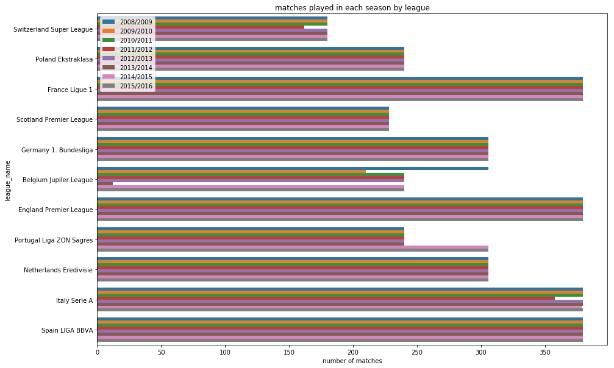

```python
# create a figure
plt.figure(figsize=(15, 10))
# create countplot from seaborn
sns.countplot(y = matches["league_name"], hue=matches["season"])

plt.title('matches played in each season by league')
plt.xlabel('number of matches')
plt.legend(loc='upper left')
```

### Research Question 2 (What are the top home & away teams that have scored goals?)

we will split this task into two subtasks. The first one is to get the top home teams from all the leagues that has scored the most goals. and the second one is the same regarding to the away teams.

```python
# total goals of the home teams
hteam_goals = matches.groupby("home_team")["home_team_goal"].sum().reset_index()
# sort them descending
hteam_goals_sorted = hteam_goals.sort_values(by='home_team_goal', ascending=False)

# total goals of the away teams
ateam_goals = matches.groupby("away_team")["away_team_goal"].sum().reset_index()
# sort them descending
ateam_goals_sorted = ateam_goals.sort_values(by='away_team_goal', ascending=False)
```

start visualizing these two dataframes using barplot from seaborn

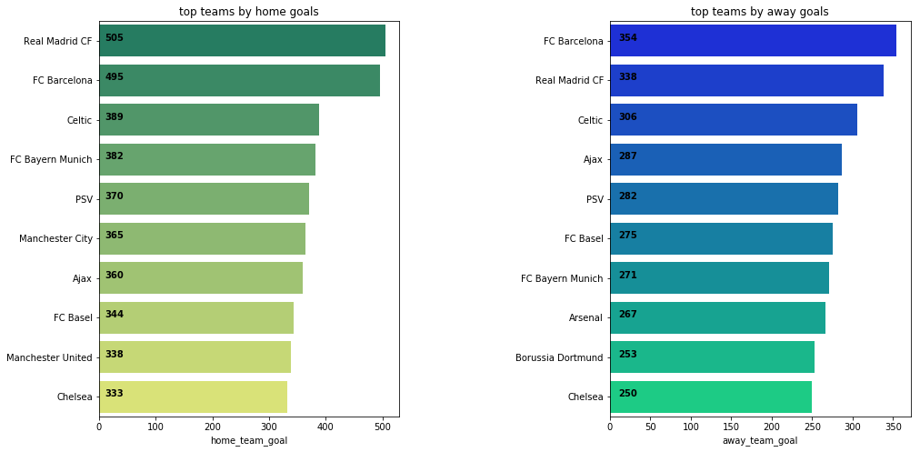

```python
# create a figure
plt.figure(figsize=(16,8))
# make two subplots side by side
plt.subplot(1,2,1)

# plotting top 10 home teams in the first side
ax = sns.barplot(data=hteam_goals_sorted[:10], x='home_team_goal', y='home_team', palette="summer")
for i, team in enumerate(hteam_goals_sorted['home_team_goal'][:10]):
    ax.text(10, i, team, weight='bold')
plt.ylabel('')
plt.title('top teams by home goals')

# plotting top 10 away teams in the second side
plt.subplot(1,2,2)
ax = sns.barplot(data=ateam_goals_sorted[:10], x='away_team_goal', y='away_team', palette="winter")
for i, team in enumerate(ateam_goals_sorted['away_team_goal'][:10]):
    ax.text(10, i, team, weight='bold')
plt.ylabel('')
plt.title('top teams by away goals')

plt.subplots_adjust(wspace=0.7)
```

**Conclusion:**

we conclude that **Barcelona** and **Real Madrid** are the most two teams in all the leagues that have scored goals whether inside or outside its court. This give an advantage to the **Spain LIGA** over the other leagues in this point.

### Research Question 3 (What are the top number of goals from home & away teams per season?)

applying `groupby` on the `matches` dataframe and getting home team goals & away team goals separately is the first step. then joining them together into one dataframe will make the task easier for plotting.

```python
# total home team goals
hteam_goals = matches.groupby(["season", "home_team"])["home_team_goal"].sum().reset_index()
# home goals by season
hteam_goals_by_season = hteam_goals.loc[hteam_goals.groupby('season')['home_team_goal'].idxmax()]

# total away team goals
ateam_goals = matches.groupby(["season", "away_team"])["away_team_goal"].sum().reset_index()
# away goals by season
ateam_goals_by_season = ateam_goals.loc[ateam_goals.groupby('season')['away_team_goal'].idxmax()]

goals = pd.merge(hteam_goals_by_season, ateam_goals_by_season, on='season')
goals
```

|  | season | home_team | home_team_goal | away_team | away_team_goal |
| --- | --- | --- | --- | --- | --- |
| 0 | 2008/2009 | FC Barcelona | 61 | FC Barcelona | 44 |
| 1 | 2009/2010 | Chelsea | 68 | Ajax | 42 |
| 2 | 2010/2011 | Real Madrid CF | 61 | FC Barcelona | 49 |
| 3 | 2011/2012 | FC Barcelona | 73 | Real Madrid CF | 51 |
| 4 | 2012/2013 | Real Madrid CF | 67 | FC Barcelona | 52 |
| 5 | 2013/2014 | FC Barcelona | 64 | Celtic | 52 |
| 6 | 2014/2015 | Real Madrid CF | 65 | Real Madrid CF | 53 |
| 7 | 2015/2016 | Real Madrid CF | 70 | PSV | 47 |

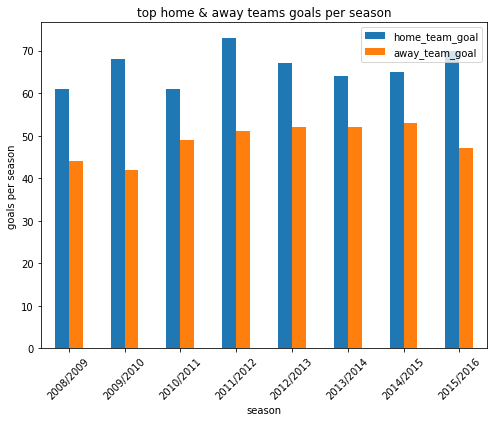

```python
# create a figure
plt.figure(figsize=(8, 10))
# create a bar plot
ax = goals.plot(kind='bar', figsize=(8, 6))

ax.set_xticklabels(goals['season'])

# apply rotation on xtick labels
for item in plt.gca().xaxis.get_ticklabels():
    item.set_rotation(45)

ax.set_xlabel('season')
ax.set_ylabel('goals per season')
ax.set_title('top home & away teams goals per season')
```

**Conclusion:**

We conclude that for all seasons, always home teams scores the most goals.

### Research Question 4 (What are the total goals have been scored in each season for every league?)

We can use *pivot table* which answer such these questions easily.

```python
table = pd.pivot_table(data=matches, index=['season', 'league_name'], values='total_goals',
                       aggfunc='sum')
table
```

| season | league_name | total_goals |
| --- | --- | --- |
| 2008/2009 | Belgium Jupiler League | 855 |
|  | England Premier League | 942 |
|  | France Ligue 1 | 858 |
|  | Germany 1. Bundesliga | 894 |
|  | Italy Serie A | 988 |
|  | Netherlands Eredivisie | 870 |
|  | Poland Ekstraklasa | 524 |
|  | Portugal Liga ZON Sagres | 552 |
|  | Scotland Premier League | 548 |
|  | Spain LIGA BBVA | 1101 |
|  | Switzerland Super League | 540 |
| 2009/2010 | Belgium Jupiler League | 565 |
|  | England Premier League | 1053 |
|  | France Ligue 1 | 916 |
|  | Germany 1. Bundesliga | 866 |
|  | Italy Serie A | 992 |
|  | Netherlands Eredivisie | 892 |
|  | Poland Ekstraklasa | 532 |
|  | Portugal Liga ZON Sagres | 601 |
|  | Scotland Premier League | 585 |
|  | Spain LIGA BBVA | 1031 |
|  | Switzerland Super League | 599 |
| 2010/2011 | Belgium Jupiler League | 635 |
|  | England Premier League | 1063 |
|  | France Ligue 1 | 890 |
|  | Germany 1. Bundesliga | 894 |
|  | Italy Serie A | 955 |
|  | Netherlands Eredivisie | 987 |
|  | Poland Ekstraklasa | 578 |
|  | Portugal Liga ZON Sagres | 584 |
| ... | ... | ... |
| 2013/2014 | Germany 1. Bundesliga | 967 |
|  | Italy Serie A | 1035 |
|  | Netherlands Eredivisie | 978 |
|  | Poland Ekstraklasa | 634 |
|  | Portugal Liga ZON Sagres | 569 |
|  | Scotland Premier League | 626 |
|  | Spain LIGA BBVA | 1045 |
|  | Switzerland Super League | 520 |
| 2014/2015 | Belgium Jupiler League | 668 |
|  | England Premier League | 975 |
|  | France Ligue 1 | 947 |
|  | Germany 1. Bundesliga | 843 |
|  | Italy Serie A | 1018 |
|  | Netherlands Eredivisie | 942 |
|  | Poland Ekstraklasa | 628 |
|  | Portugal Liga ZON Sagres | 763 |
|  | Scotland Premier League | 587 |
|  | Spain LIGA BBVA | 1009 |
|  | Switzerland Super League | 517 |
| 2015/2016 | Belgium Jupiler League | 694 |
|  | England Premier League | 1026 |
|  | France Ligue 1 | 960 |
|  | Germany 1. Bundesliga | 866 |
|  | Italy Serie A | 979 |
|  | Netherlands Eredivisie | 912 |
|  | Poland Ekstraklasa | 635 |
|  | Portugal Liga ZON Sagres | 831 |
|  | Scotland Premier League | 650 |
|  | Spain LIGA BBVA | 1043 |
|  | Switzerland Super League | 566 |

88 rows × 1 columns

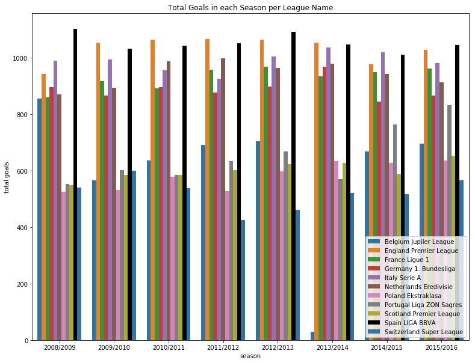

```python
plt.figure(figsize=(13, 10))
# reset index for making the visualization easy to access the pivot table
new = table.reset_index()
# apply barplot
sns.barplot(data=new, x='season', y='total_goals', hue='league_name',
            palette=["C0","C1","C2","C3", "C4","C5","C6","C7","C8","k"])

plt.title('Total Goals in each Season per League Name')
plt.ylabel('total goals')
plt.legend(loc='lower right')
```

### Research Question 5 (What are the number of goals have been scored in the premier league in each seasons?)

filter `matches` dataframe to get only the matches of the Premier league

```python
england_matches = matches[matches['country_name'] == 'England']
england_matches.head()
```

|  | id | country_name | league_name | season | stage | date | home_team | away_team | home_team_goal | away_team_goal | total_goals | home_team_win |
| --- | --- | --- | --- | --- | --- | --- | --- | --- | --- | --- | --- | --- |
| 58 | 1730 | England | England Premier League | 2008/2009 | 1 | 2008-08-16 00:00:00 | Arsenal | West Bromwich Albion | 1 | 0 | 1 | 1 |
| 59 | 1731 | England | England Premier League | 2008/2009 | 1 | 2008-08-16 00:00:00 | Sunderland | Liverpool | 0 | 1 | 1 | 0 |
| 60 | 1732 | England | England Premier League | 2008/2009 | 1 | 2008-08-16 00:00:00 | West Ham United | Wigan Athletic | 2 | 1 | 3 | 1 |
| 61 | 1734 | England | England Premier League | 2008/2009 | 1 | 2008-08-16 00:00:00 | Everton | Blackburn Rovers | 2 | 3 | 5 | 0 |
| 62 | 1735 | England | England Premier League | 2008/2009 | 1 | 2008-08-16 00:00:00 | Middlesbrough | Tottenham Hotspur | 2 | 1 | 3 | 1 |

```python
# apply groupby to get goals per season
england_goals = england_matches.groupby('season')['home_team_goal'].sum().reset_index()
england_goals
```

|  | season | home_team_goal |
| --- | --- | --- |
| 0 | 2008/2009 | 532 |
| 1 | 2009/2010 | 645 |
| 2 | 2010/2011 | 617 |
| 3 | 2011/2012 | 604 |
| 4 | 2012/2013 | 592 |
| 5 | 2013/2014 | 598 |
| 6 | 2014/2015 | 560 |
| 7 | 2015/2016 | 567 |

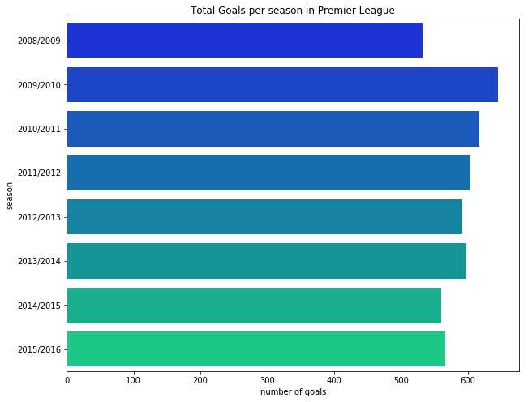

```python
# create bar plot
plt.figure(figsize=(10, 8))
sns.barplot(data=england_goals, y='season', x='home_team_goal', palette='winter')

plt.title('Total Goals per season in Premier League')
plt.xlabel('number of goals')
```

### Research Question 6 (What is the performance of each team in the premier league?)

we want to know for every team how many times it won, lose or draw. so we want to add this columns to `england_matches` dataframe

```python
def home_team_result(row):
    if row['home_team_goal'] > row['away_team_goal']:
        return 'win'
    elif row['home_team_goal'] < row['away_team_goal']:
        return 'lose'
    else:
        return 'draw'


def away_team_result(row):
    if row['home_team_goal'] > row['away_team_goal']:
        return 'lose'
    elif row['home_team_goal'] < row['away_team_goal']:
        return 'win'
    else:
        return 'draw'



england_matches['home_team_result'] = england_matches.apply(lambda row: home_team_result(row), axis=1)
england_matches['away_team_result'] = england_matches.apply(lambda row: away_team_result(row), axis=1)
england_matches.head()
```

|  | id | country_name | league_name | season | stage | date | home_team | away_team | home_team_goal | away_team_goal | total_goals | home_team_win | home_team_result | away_team_result |
| --- | --- | --- | --- | --- | --- | --- | --- | --- | --- | --- | --- | --- | --- | --- |
| 58 | 1730 | England | England Premier League | 2008/2009 | 1 | 2008-08-16 00:00:00 | Arsenal | West Bromwich Albion | 1 | 0 | 1 | 1 | win | lose |
| 59 | 1731 | England | England Premier League | 2008/2009 | 1 | 2008-08-16 00:00:00 | Sunderland | Liverpool | 0 | 1 | 1 | 0 | lose | win |
| 60 | 1732 | England | England Premier League | 2008/2009 | 1 | 2008-08-16 00:00:00 | West Ham United | Wigan Athletic | 2 | 1 | 3 | 1 | win | lose |
| 61 | 1734 | England | England Premier League | 2008/2009 | 1 | 2008-08-16 00:00:00 | Everton | Blackburn Rovers | 2 | 3 | 5 | 0 | lose | win |
| 62 | 1735 | England | England Premier League | 2008/2009 | 1 | 2008-08-16 00:00:00 | Middlesbrough | Tottenham Hotspur | 2 | 1 | 3 | 1 | win | lose |

```python
# get home & away team results dataframes
hteam_results = pd.DataFrame(england_matches.groupby('home_team')['home_team_result'].value_counts())
ateam_results = pd.DataFrame(england_matches.groupby('away_team')['away_team_result'].value_counts())

# rename index (make the two dataframes has the same index name) to merge the two dataframes on index
hteam_results.index = hteam_results.index.rename(['team', 'team_result'])
ateam_results.index = ateam_results.index.rename(['team', 'team_result'])
```

```python
# merge the two dataframes
teams_results = hteam_results.merge(ateam_results, left_on=['team', 'team_result'], right_on=['team', 'team_result']
                                    , how='inner')
# add total_result column
teams_results['total_result'] = teams_results['home_team_result'] + teams_results['away_team_result']

# remove columns
teams_results = teams_results.drop(columns=['home_team_result', 'away_team_result'], axis=1)

teams_results = teams_results.reset_index()
#teams_results = teams_results.T
teams_results
```

|  | team | team_result | total_result |
| --- | --- | --- | --- |
| 0 | Arsenal | win | 170 |
| 1 | Arsenal | draw | 73 |
| 2 | Arsenal | lose | 61 |
| 3 | Aston Villa | lose | 130 |
| 4 | Aston Villa | draw | 88 |
| 5 | Aston Villa | win | 86 |
| 6 | Birmingham City | draw | 26 |
| 7 | Birmingham City | win | 21 |
| 8 | Birmingham City | lose | 29 |
| 9 | Blackburn Rovers | win | 42 |
| 10 | Blackburn Rovers | lose | 71 |
| 11 | Blackburn Rovers | draw | 39 |
| 12 | Blackpool | lose | 19 |
| 13 | Blackpool | draw | 9 |
| 14 | Blackpool | win | 10 |
| 15 | Bolton Wanderers | lose | 76 |
| 16 | Bolton Wanderers | win | 43 |
| 17 | Bolton Wanderers | draw | 33 |
| 18 | Bournemouth | lose | 18 |
| 19 | Bournemouth | draw | 9 |
| 20 | Bournemouth | win | 11 |
| 21 | Burnley | lose | 43 |
| 22 | Burnley | draw | 18 |
| 23 | Burnley | win | 15 |
| 24 | Cardiff City | lose | 22 |
| 25 | Cardiff City | draw | 9 |
| 26 | Cardiff City | win | 7 |
| 27 | Chelsea | win | 176 |
| 28 | Chelsea | draw | 70 |
| 29 | Chelsea | lose | 58 |
| ... | ... | ... | ... |
| 72 | Southampton | win | 60 |
| 73 | Southampton | draw | 40 |
| 74 | Southampton | lose | 52 |
| 75 | Stoke City | win | 98 |
| 76 | Stoke City | draw | 86 |
| 77 | Stoke City | lose | 120 |
| 78 | Sunderland | lose | 134 |
| 79 | Sunderland | win | 78 |
| 80 | Sunderland | draw | 92 |
| 81 | Swansea City | win | 62 |
| 82 | Swansea City | draw | 52 |
| 83 | Swansea City | lose | 76 |
| 84 | Tottenham Hotspur | win | 151 |
| 85 | Tottenham Hotspur | draw | 74 |
| 86 | Tottenham Hotspur | lose | 79 |
| 87 | Watford | lose | 17 |
| 88 | Watford | draw | 9 |
| 89 | Watford | win | 12 |
| 90 | West Bromwich Albion | lose | 118 |
| 91 | West Bromwich Albion | win | 75 |
| 92 | West Bromwich Albion | draw | 73 |
| 93 | West Ham United | win | 80 |
| 94 | West Ham United | lose | 112 |
| 95 | West Ham United | draw | 74 |
| 96 | Wigan Athletic | lose | 88 |
| 97 | Wigan Athletic | draw | 52 |
| 98 | Wigan Athletic | win | 50 |
| 99 | Wolverhampton Wanderers | lose | 61 |
| 100 | Wolverhampton Wanderers | win | 25 |
| 101 | Wolverhampton Wanderers | draw | 28 |

102 rows × 3 columns

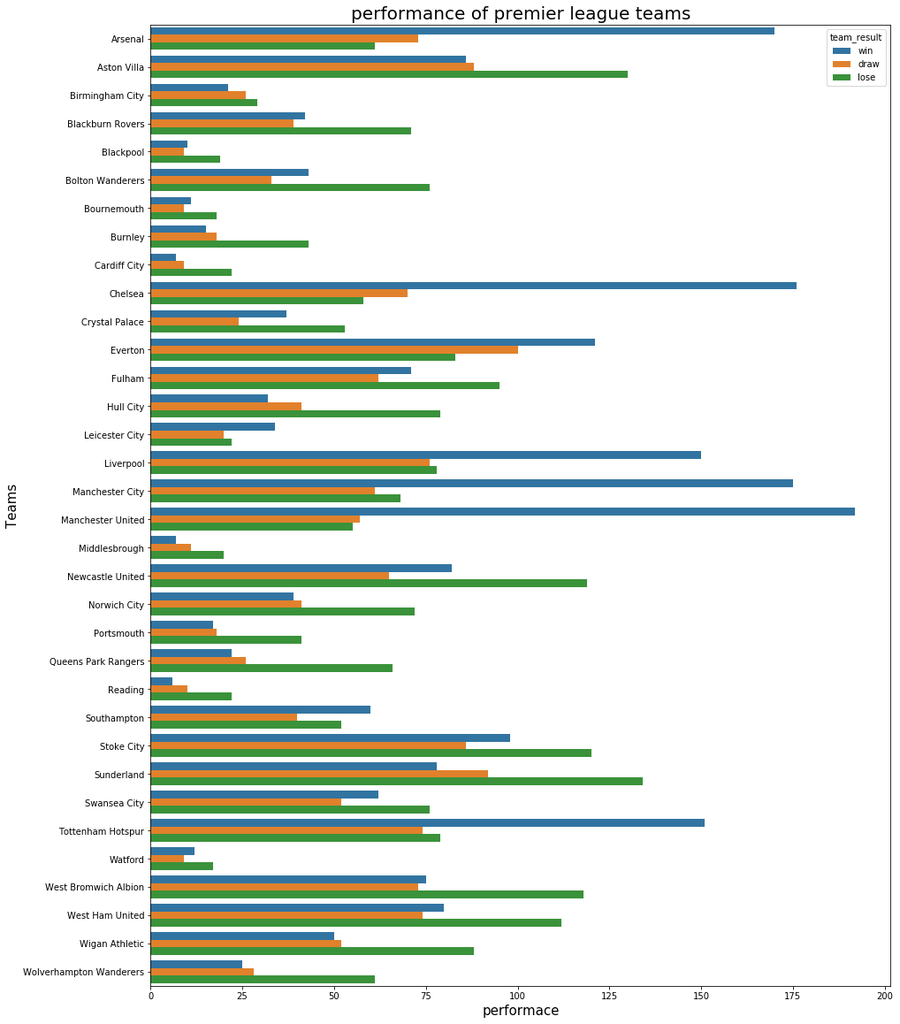

```python
# create bar plot
plt.figure(figsize=(15, 20))
sns.barplot(data=teams_results, y='team', hue='team_result', x='total_result', linewidth=5)

plt.title('performance of premier league teams', fontsize=20)
plt.xlabel('performace', fontsize=15)
plt.ylabel('Teams', fontsize=15)
```

### Research Question 7 (What are the top winner teams per each league?)

To answer this question, we need to add new column which has the name of the winner team per match. so we can group the dataframe by the `league_name` and count for every team number of wins.

```python
# add winner column
def winner(row):
    if row['home_team_goal'] > row['away_team_goal']:
        return row['home_team']
    elif row['home_team_goal'] < row['away_team_goal']:
        return row['away_team']
    else:
        return 'draw'

matches['winner'] = matches.apply(lambda row: winner(row), axis=1)
```

```python
# group them by the league name and the winner team
winners = matches.groupby(['league_name', 'winner'])['winner'].count()
winners = winners.reset_index(name='wins')
# remove the 'draw' values in the 'winner' column
winners = winners[winners['winner'] != 'draw']
# sort them by number of wins descendingly
winners = winners.sort_values(by='wins', ascending=False)
# keep only the first winner team
winners = winners.drop_duplicates(subset=['league_name'], keep='first')
winners
```

|  | league_name | winner | wins |
| --- | --- | --- | --- |
| 264 | Spain LIGA BBVA | FC Barcelona | 234 |
| 240 | Scotland Premier League | Celtic | 218 |
| 107 | Germany 1. Bundesliga | FC Bayern Munich | 193 |
| 42 | England Premier League | Manchester United | 192 |
| 142 | Italy Serie A | Juventus | 189 |
| 230 | Portugal Liga ZON Sagres | SL Benfica | 185 |
| 162 | Netherlands Eredivisie | Ajax | 181 |
| 294 | Switzerland Super League | FC Basel | 180 |
| 84 | France Ligue 1 | Paris Saint-Germain | 175 |
| 194 | Poland Ekstraklasa | Legia Warszawa | 137 |
| 15 | Belgium Jupiler League | RSC Anderlecht | 136 |

it became too easy to plot!

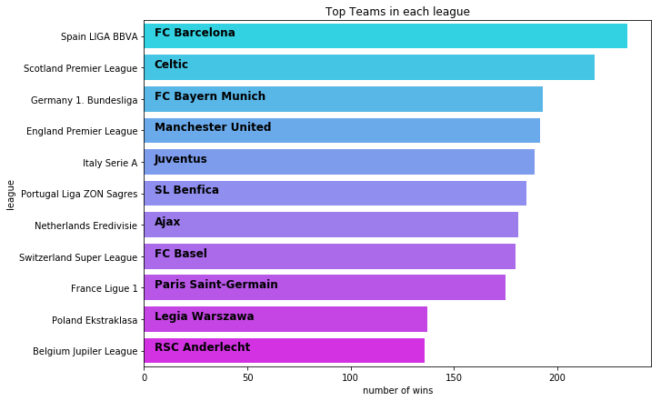

```python
# create barplot
plt.figure(figsize=(10, 7))
ax = sns.barplot(data=winners, x='wins', y='league_name', palette='cool')

plt.xlabel('number of wins')
plt.ylabel('league')
plt.title('Top Teams in each league')

# write team name on the bar plot
for i, team in enumerate(winners['winner']):
    ax.text(5, i, team, weight='bold', fontsize=12)
```

**Conclusion:**

**Barcelona** is the most winner team in the **Spain LIGA** and also between all the teams in each league.

### Research Question 8 (What are the number of played matches and scored goals in each league?)

we can make it in only one step using groupby with aggregate functions!

```python
leagues_comp = matches.groupby('league_name').agg({'id': 'count', 'total_goals': 'sum'}) \
                              .rename(columns={'id': 'total_matches'})
leagues_comp
```

| league_name | total_matches | total_goals |
| --- | --- | --- |
| Belgium Jupiler League | 1728 | 4841 |
| England Premier League | 3040 | 8240 |
| France Ligue 1 | 3040 | 7427 |
| Germany 1. Bundesliga | 2448 | 7103 |
| Italy Serie A | 3017 | 7895 |
| Netherlands Eredivisie | 2448 | 7542 |
| Poland Ekstraklasa | 1920 | 4656 |
| Portugal Liga ZON Sagres | 2052 | 5201 |
| Scotland Premier League | 1824 | 4804 |
| Spain LIGA BBVA | 3040 | 8412 |
| Switzerland Super League | 1422 | 4166 |

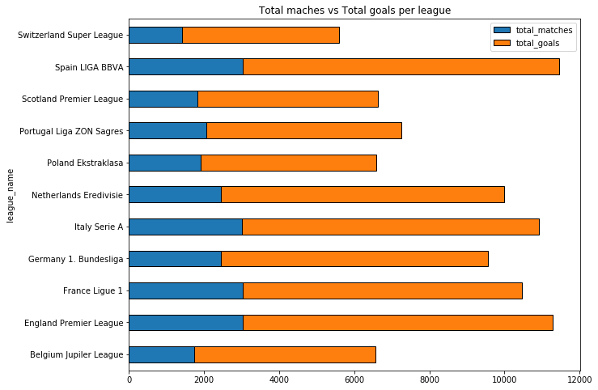

```python
leagues_comp.plot(kind='barh',
                  stacked=True,
                  figsize=(10,8),
                  linewidth=1,
                  edgecolor='k'*matches['league_name'].nunique())

plt.title('Total maches vs Total goals per league')
```

### Research Question 9 (What are the number of goals scored for each league in all seasons ?)

using the `leagues_comp` dataframe we made earlier, It will be direct plotting.

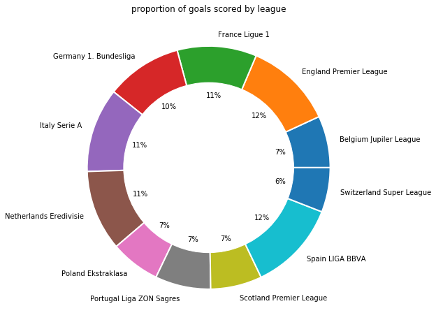

```python
leagues_comp['total_goals'].plot(kind='pie',
                                 figsize=(10, 8),
                                 autopct='%1.0f%%',
                                 wedgeprops={"linewidth":2,"edgecolor":"white"})

plt.ylabel('')
plt.title('proportion of goals scored by league')

# add new artist style for pie chart
circle = plt.Circle((0,0), 0.7, color='white')
plt.gca().add_artist(circle)
```

**Conclusion:**

The most scored goals are from the **Spain LIGA** and **Preimier League**.

### Research Question 10 (What are the number of goals scored in each league for each season seperately?)

we can use pivot table to get the `season` as index and every `league_name` as a column.

```python
table = pd.pivot_table(data=matches, index='season', columns='league_name', values='total_goals',
                      aggfunc='sum')
table
```

| league_name season | Belgium Jupiler League | England Premier League | France Ligue 1 | Germany 1. Bundesliga | Italy Serie A | Netherlands Eredivisie | Poland Ekstraklasa | Portugal Liga ZON Sagres | Scotland Premier League | Spain LIGA BBVA | Switzerland Super League |
| --- | --- | --- | --- | --- | --- | --- | --- | --- | --- | --- | --- |
| 2008/2009 | 855 | 942 | 858 | 894 | 988 | 870 | 524 | 552 | 548 | 1101 | 540 |
| 2009/2010 | 565 | 1053 | 916 | 866 | 992 | 892 | 532 | 601 | 585 | 1031 | 599 |
| 2010/2011 | 635 | 1063 | 890 | 894 | 955 | 987 | 578 | 584 | 584 | 1042 | 537 |
| 2011/2012 | 691 | 1066 | 956 | 875 | 925 | 997 | 527 | 634 | 601 | 1050 | 425 |
| 2012/2013 | 703 | 1063 | 967 | 898 | 1003 | 964 | 598 | 667 | 623 | 1091 | 462 |
| 2013/2014 | 30 | 1052 | 933 | 967 | 1035 | 978 | 634 | 569 | 626 | 1045 | 520 |
| 2014/2015 | 668 | 975 | 947 | 843 | 1018 | 942 | 628 | 763 | 587 | 1009 | 517 |
| 2015/2016 | 694 | 1026 | 960 | 866 | 979 | 912 | 635 | 831 | 650 | 1043 | 566 |

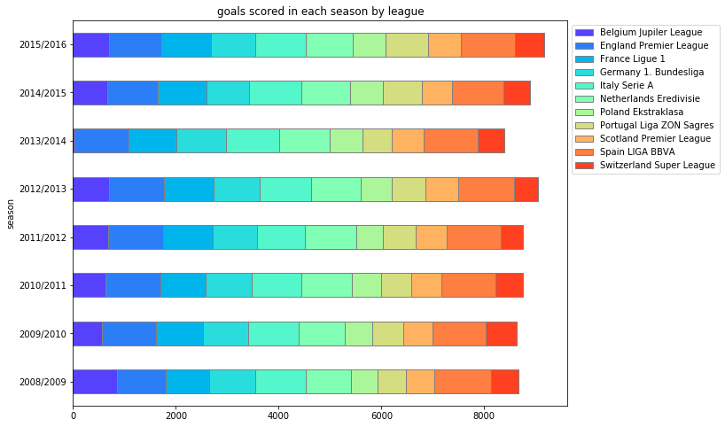

```python
table.plot(kind='barh',
           stacked=True,
           figsize=(10, 8),
           color=sns.color_palette('rainbow', 11),
           edgecolor='grey')

plt.title('goals scored in each season by league')
plt.legend(bbox_to_anchor=(1,1))
```

### Research Question 11 (What are the top winners teams in the Spain LIGA per season?)

It's the same. we will group them by `season`, `league_name` and `winner` team. then apply a filter to the rows to get only the **Spain LIGA**

```python
# group them by the season and league name and winner team
season_winners = matches.groupby(['season', 'league_name', 'winner'])['winner'].count()
season_winners = season_winners.reset_index(name='wins')
# remove 'draw' values from the winner column
season_winners = season_winners[season_winners['winner'] != 'draw']
# sort them descendingly by wins
season_winners = season_winners.sort_values(by='wins', ascending=False)
# drop duplicates from season and league name
season_winners = season_winners.drop_duplicates(subset=['season', 'league_name'], keep='first').sort_values(by=["season"],ascending =True)
# get premier league seasons
spain_season_winners = season_winners[season_winners['league_name'] == 'Spain LIGA BBVA']
spain_season_winners
```

|  | season | league_name | winner | wins |
| --- | --- | --- | --- | --- |
| 170 | 2008/2009 | Spain LIGA BBVA | FC Barcelona | 27 |
| 373 | 2009/2010 | Spain LIGA BBVA | Real Madrid CF | 31 |
| 561 | 2010/2011 | Spain LIGA BBVA | FC Barcelona | 30 |
| 767 | 2011/2012 | Spain LIGA BBVA | Real Madrid CF | 32 |
| 954 | 2012/2013 | Spain LIGA BBVA | FC Barcelona | 32 |
| 1137 | 2013/2014 | Spain LIGA BBVA | Atlético Madrid | 28 |
| 1348 | 2014/2015 | Spain LIGA BBVA | Real Madrid CF | 30 |
| 1536 | 2015/2016 | Spain LIGA BBVA | FC Barcelona | 29 |

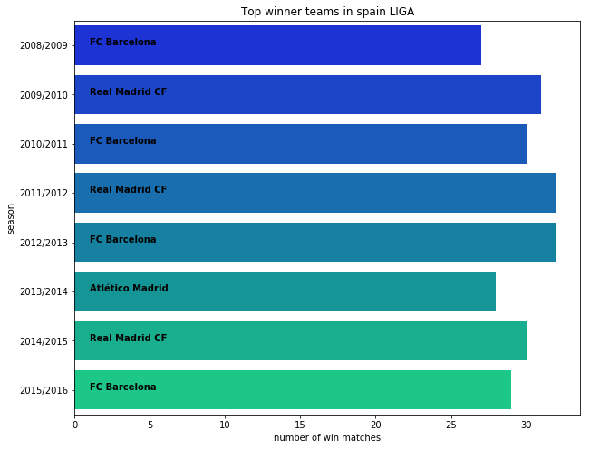

```python
# create bar plot
plt.figure(figsize=(10, 8))
ax = sns.barplot(data=spain_season_winners, x='wins', y='season', palette='winter')

# write team name on the bar plot
for i, team in enumerate(spain_season_winners['winner']):
    ax.text(1, i, team, weight='bold')

plt.title('Top winner teams in spain LIGA')
plt.xlabel('number of win matches')
```

**Conclusion:**

**Barcelona** is the most winner team with the **Spain LIGA** from 2008 to 2016

## Conclusions

Finally, We can do more and more analysis and visualization work on this great database. But this was a samll part of making **data wrangling** with some **Explatory Data Analysis (EDA)** to get some insights from the dataset. After getting more information and insights, It will be easier to choose the best machine learning model that fit the data well and avoid its limitation!

**Resources:**

- https://www.kaggle.com/dimarudov/data-analysis-using-sql
- https://www.kaggle.com/pavanraj159/european-football-data-analysis